# Albany, NY Legal Marijuana Legislation: Racial Equity Focus

#### Racial Impact of Licensing Policy Based on Alcohol Licenses

[figure not shown]

*Detail of South End's Census Tract 25. Red outlined properties are those that potentially would be unavailable for marijuana sales if licensing policy prohibits sales within 500ft of churches and or schools. Yellow outlined properties are churches or schools.*

Report by Marco Flagg  
Email: marco.flagg@tanhandmedia.com

### Part A: Research Methodology

The following is a summary of the dataset characteristics and research methodology employed in this report.

#### 1. Dataset Characteristics

Census Tract Demographics  
Basing research dataset boundaries on census tracts gives opportunities to link the MapGeo tool's rich property information with the census's extensive historical demographic data. Combining micro and macro-level data will assist in tying local community phenomena to broader systemic issues. Therefore this approach is beneficial when analyzing racial equity impact.  
For example, note in the below census tract demographics table that all four majority Black communities have lower median household incomes than the two majority White communities. The location of these income disparities can be traced back through the decades to at least the early twentieth century's redlining policy where the city and banking institutions enforced economic oppression targetted against those same Black communities.

```python
# Display Census Tract Demographics table
ctract_demographics_df
```

|  | place | zip_code | census_tract | majority_race | population | median_household_income | percent_owner_occupied_housing |
| --- | --- | --- | --- | --- | --- | --- | --- |
| 0 | North Albany | 12207 | 1 | black | 2073 | 32389 | 26.854599 |
| 1 | Arbor Hill | 12210 | 2 | black | 4793 | 27714 | 18.212694 |
| 2 | Pine Hills | 12208 | 16 | white | 4290 | 50417 | 35.429326 |
| 3 | Pine Hills | 12208 | 17 | white | 4016 | 63913 | 53.347681 |
| 4 | South End | 12202 | 25 | black | 3208 | 24425 | 5.723660 |
| 5 | South End | 12202 | 26 | black | 5179 | 38494 | 46.183206 |

[figure not shown]

*Fig. 1) The highlighted borders of selected Albany census tracts.*

#### 2. Methodology

*For additional research details view the link below:  
[Research Methodology Details](https://github.com/elviktor/thm-consulting/blob/main/Weed/Racial%20Impact%20of%20Licensing%20Policy/weed_license_policy_map_EDA_01_Data_Prep.ipynb)

Steps to create `Available Properties Datasets` for target census tracts:  
1) Select census tracts that represent the areas of comparison discussed in the above *Dataset Characteristics* section.

2) Make [Mapgeo](https://albanyny.mapgeo.io/) tool selections that trace the target census tracts' borders.

[figure not shown]

*Fig. 2) The borders of Census Tract 16.*  
3) Export the target census tracts' metadata.

4) Identify churches and schools by the census tracts' *Property Class* (codes 612, 615, 620).

5) Use the [Mapgeo](https://albanyny.mapgeo.io/) tool to select church and school properties within selected census tracts.

6) Discover abutters with [Mapgeo](https://albanyny.mapgeo.io/) tool.

[figure not shown]

*Fig. 3) Unavailable properties in Census Tract 16 (those within 500ft of churches and or schools) are highlighted red.*  
7) Create *Available Properties Datasets* made up of the properties that are outside of abutters zone that would possibly qualify for marijuana industry licenses in all selected census tracts. Use the following abutter distances (in feet): 500, 200, & 100.

[figure not shown]

*Fig. 4) Available properties in Census Tract 16 (those further than 500ft from churches and or schools) are highlighted green.*  
8) Perform analysis of the *Available Properties Datasets* in seperate notebook:  
[Data Analysis Details](https://github.com/elviktor/thm-consulting/blob/main/Weed/Racial%20Impact%20of%20Licensing%20Policy/weed_license_policy_map_EDA_02_Available_Property_Exploration.ipynb)

### Part B: Analysis of the *Available Properties Datasets* for target census tracts

#### 1. Prepare Data

View the Utilities Section for code details.

#### 2. Compare Percentage Decrease in Available Properties

Comparing the percentage of decrease in available mixed-use properties across census tracts and abutter distances can help us see if the distance requirements of a liquor license based policy would impact Albany neighborhoods equally.  
The policy may not be equitable if percent decrease in available mixed-use properties (`mu_change`) is higher in majority Black neighborhoods (2, 25 & 26) compared to majority White neighborhoods (16 & 17).

##### 3. Findings

South End (*label prefix 25*) and Arbor Hill (*label prefix 02*) census tracts have the largest percentage decreases in available Mixed-Use (`mu`) districts when licensing restrictions of 500, 200 and 100 feet away from schools and churches are applied.

a. Percentage change in available properties with 500ft license restriction

```python
# Display table of percentage change in residential (r_change), mixed use (mu_change) & industrial (i) properties in selected census tracts when license restriction is 500ft from schools and churches.
graph_500_df = zone_change_df.query('distance == "500"').sort_values(by=['mu_change'])
graph_500_df
```

|  | ctract | distance | r | mu | i | r_change | mu_change | i_change |
| --- | --- | --- | --- | --- | --- | --- | --- | --- |
| 25-500 | 25 | 500 | 116 | 65 | 0 | -83.333333 | -82.432432 | 0.000000 |
| 02-500 | 02 | 500 | 259 | 79 | 8 | -79.781421 | -76.764706 | -38.461538 |
| 16-500 | 16 | 500 | 422 | 30 | 0 | -57.630522 | -75.609756 | 0.000000 |
| 17-500 | 17 | 500 | 561 | 26 | 0 | -48.151571 | -69.047619 | 0.000000 |
| 26-500 | 26 | 500 | 575 | 122 | 17 | -56.831832 | -58.075601 | -63.043478 |
| 01-500 | 01 | 500 | 364 | 98 | 11 | -30.666667 | -42.011834 | -57.692308 |

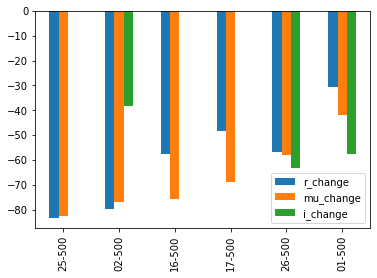

```python
# Display graph of percentage change in residential (r_change), mixed use (mu_change) & industrial (i) properties in selected census tracts when license restriction is 500ft from schools and churches.
graph_500_df.drop(labels=['r','mu','i'], axis=1, inplace=True)
graph_500_df.plot(kind='bar');
```

b. Percentage change in available properties with 200ft license restriction

```python
# Display table of percentage change in residential (r_change), mixed use (mu_change) & industrial (i) properties in selected census tracts when license restriction is 500ft from schools and churches.
graph_200_df = zone_change_df.query('distance == "200"').sort_values(by=['mu_change'])
graph_200_df
```

|  | ctract | distance | r | mu | i | r_change | mu_change | i_change |
| --- | --- | --- | --- | --- | --- | --- | --- | --- |
| 25-200 | 25 | 200 | 326 | 133 | 0 | -53.160920 | -64.054054 | 0.000000 |
| 02-200 | 02 | 200 | 813 | 180 | 9 | -36.533958 | -47.058824 | -30.769231 |
| 16-200 | 16 | 200 | 695 | 76 | 0 | -30.220884 | -38.211382 | 0.000000 |
| 17-200 | 17 | 200 | 811 | 53 | 0 | -25.046211 | -36.904762 | 0.000000 |
| 26-200 | 26 | 200 | 1012 | 212 | 36 | -24.024024 | -27.147766 | -21.739130 |
| 01-200 | 01 | 200 | 427 | 128 | 21 | -18.666667 | -24.260355 | -19.230769 |

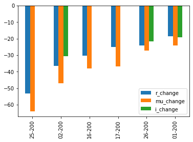

```python
# Display graph of percentage change in residential (r_change), mixed use (mu_change) & industrial (i) properties in selected census tracts when license restriction is 200ft from schools and churches.
graph_200_df.drop(labels=['r','mu','i'], axis=1, inplace=True)
graph_200_df.plot(kind='bar');
```

c. Percentage change in available properties with 100ft license restriction

```python
# Display table of percentage change in residential (r_change), mixed use (mu_change) & industrial (i) properties in selected census tracts when license restriction is 100ft from schools and churches.
graph_100_df = zone_change_df.query('distance == "100"').sort_values(by=['mu_change'])
graph_100_df
```

|  | ctract | distance | r | mu | i | r_change | mu_change | i_change |
| --- | --- | --- | --- | --- | --- | --- | --- | --- |
| 25-100 | 25 | 100 | 496 | 200 | 0 | -28.735632 | -45.945946 | 0.000000 |
| 02-100 | 02 | 100 | 1004 | 225 | 9 | -21.623731 | -33.823529 | -30.769231 |
| 17-100 | 17 | 100 | 862 | 58 | 0 | -20.332717 | -30.952381 | 0.000000 |
| 16-100 | 16 | 100 | 791 | 90 | 0 | -20.582329 | -26.829268 | 0.000000 |
| 26-100 | 26 | 100 | 1154 | 232 | 37 | -13.363363 | -20.274914 | -19.565217 |
| 01-100 | 01 | 100 | 466 | 144 | 21 | -11.238095 | -14.792899 | -19.230769 |

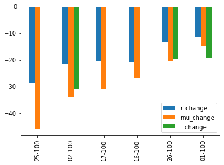

```python
# Display graph of percentage change in residential (r_change), mixed use (mu_change) & industrial (i) properties in selected census tracts when license restriction is 100ft from schools and churches.
graph_100_df.drop(labels=['r','mu','i'], axis=1, inplace=True)
graph_100_df.plot(kind='bar');
```

#### Outcome

For the coming slate of marijuana policy to be truly equitable, majority Black communities of Albany that have suffered from over a century of systemic racist policies and the war on drugs - should not have to suffer additional harm. Yet, the above analysis shows that if marijuana licenses are based on the distancing restrictions of current liquor license policy South End and Arbor Hill - two of Albany's historic Black communities - will have the highest decrease in available properties zoned for multiple use. Reducing the amount of available business space will put those Black and Brown community members at a disadvantage to their neighbors. Therefore the licensing policy that Albany is currently considering does not hold to the racial equity goals that are guiding NY state marijuana policy.

#### Recommendation

We recommend that Albany bases marijuana policy on current tobacco sales policy that does not place distance-based restrictions on licenses.  
Find a link to current NY guidance for retail tobacco dealers below:  
[A Guide for Retail Tobacco Dealers](https://www.health.ny.gov/prevention/tobacco_control/retail_tobacco_dealers_guide.htm)  
The NY state policies are sensible and stated with the purpose to reduce the exposure of youth to tobacco products. Among the dozen guidelines, only tobacco advertisements are restricted by distance. Reducing distance restrictions on businesses will cause less barriers to potential marijuana businesses across the city - including majority Black communities.

#### Utilities

```python
# Import required libraries
import pandas as pd
import numpy as np
import matplotlib.pyplot as plt
import os

# helpers.py has several helpful utilities that I have created
from helpers import available_zones_df_generator, available_change_df_generator

%matplotlib inline
```

```python
# Import DataFrames
ctract_demographics_df = pd.read_csv(os.path.join('data','albany_census_tract_demographics.csv'))
```

```python
# ENTER selected Census Tracts in following list variable:
CTRACT_LIST = ['01','02','16','17','25','26']
DISTANCE_LIST = ['0', '100', '200', '500']
```

```python
# Generate tally of available residential (r), mixed use (mu) & industrial (i) property zones using `helpers.py` script.
zone_count_df = available_zones_df_generator(CTRACT_LIST, DISTANCE_LIST)

# Rename and drop columns.
zone_count_df.drop(labels="LC", inplace=True, axis=1)
zone_count_df.rename(columns=lambda x: x.strip().lower().replace(" ", "_"), inplace=True)
```

```python
# Generate percentage change of available property zones using helpers.py script.
zone_change_df = available_change_df_generator(CTRACT_LIST, DISTANCE_LIST, zone_count_df)
```